# NOAA Storm Data Analysis - Harmful Events

Bruno Lavoie

February 3, 2016

# Synopsis

This analysis explores severe weather events types and their impacts across the United States.

Conclusions show that in USA in the period 1950 - 2011:

- Tornado and high temperature the most dangerous for health
- Floods and tornados (again) are most dangerous for economy

# Introduction

Storms and other severe weather events can cause both public health and economic problems for communities and municipalities. Many severe events can result in fatalities, injuries, and property damage, and preventing such outcomes to the extent possible is a key concern.

This project involves exploring the U.S. National Oceanic and Atmospheric Administration’s (NOAA) storm database. This database tracks characteristics of major storms and weather events in the United States, including when and where they occur, as well as estimates of any fatalities, injuries, and property damage.

# Loading packages

We load packages that we’ll use along the analysis. These must be installed for the report be reproductible.

```r
library(ggplot2)
library(dplyr)
```

# Data Processing

We download data only if it doesn’t exists yet. Then, if the storm.data data frame doesn’t exists, we load if from original data.

```r
if(!file.exists("./data")) {
  file.url <- "https://d396qusza40orc.cloudfront.net/repdata%2Fdata%2FStormData.csv.bz2"
  dir.create("./data")
  download.file(file.url, destfile="data/data.csv.bz2", method="curl")
  rm(file.url)
}
```

Loading data, relatively long, so we enable cache for this snippet in R markdown. For standalone execution, we also check if data frame is not already loaded.

```r
if (!(exists('storm.data') && is.data.frame(storm.data))) {
  storm.data <- read.csv("./data/data.csv.bz2", stringsAsFactors = FALSE)
}
```

Looking at data, most important columns used for analysis are:

- FATALTIES : Number of fatalities caused by the events
- INJURIES : Number of people injured by the events
- PROPDMG : Amount of property loss by the events
- CROPDMG : Amount of crop damage by the weather

For more information about the dataset and all metadata, please go to:

- National Weather Service [Storm Data Documentation](https://d396qusza40orc.cloudfront.net/repdata%2Fpeer2_doc%2Fpd01016005curr.pdf)
- National Climatic Data Center Storm Events [FAQ](https://d396qusza40orc.cloudfront.net/repdata%2Fpeer2_doc%2FNCDC%20Storm%20Events-FAQ%20Page.pdf)

# Results

Here we describe most harmful events types on health and economy.

## Events with greatest population health consequences

Health side of disasters, represented by FATALITIES and INJURIES numbers.

Make aggregates.

```r
health.agg <- storm.data %>%
  group_by(EVTYPE) %>%
  summarize(FATALITIES = sum(FATALITIES), INJURIES = sum(INJURIES)) %>%
  filter(FATALITIES  > 0 & INJURIES > 0)

top.fatalities <- health.agg[order(health.agg$FATALITIES, decreasing = TRUE)[1:10],]%>%
  select(EVTYPE, FATALITIES)

top.injuries   <- health.agg[order(health.agg$INJURIES,   decreasing = TRUE)[1:10],] %>%
  select(EVTYPE, INJURIES)
```

Plot them.

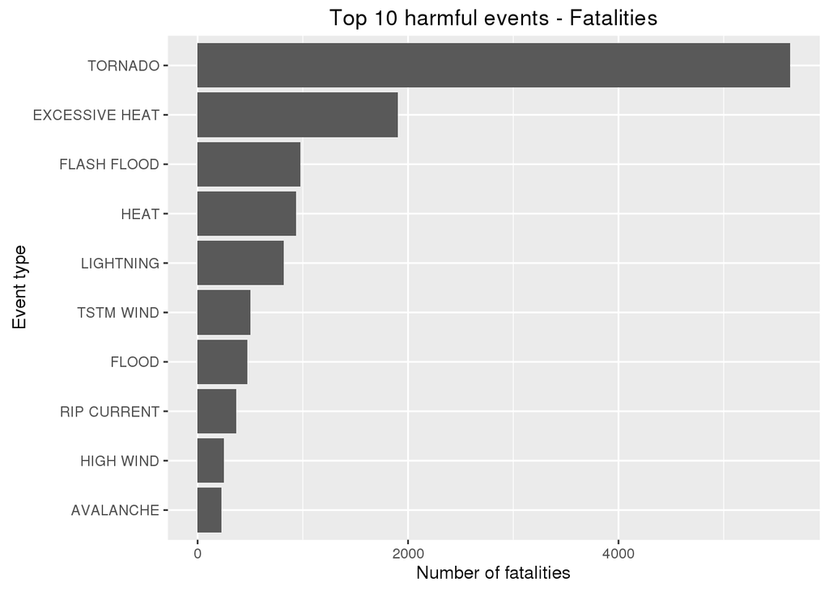

```r
ggplot(top.fatalities, aes(reorder(EVTYPE, FATALITIES), FATALITIES)) +
  geom_bar(stat = "identity") +
  coord_flip() +
  xlab("Event type") +
  ylab("Number of fatalities") +
  labs(title= "Top 10 harmful events - Fatalities")
```

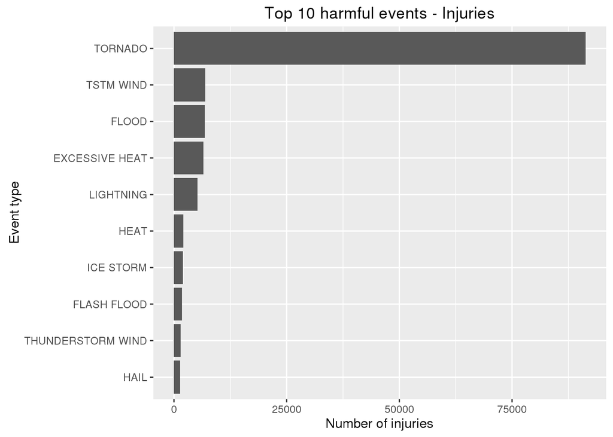

```r
ggplot(top.injuries, aes(reorder(EVTYPE, INJURIES), INJURIES)) +
  geom_bar(stat = "identity") +
  coord_flip() +
  xlab("Event type") +
  ylab("Number of injuries") +
  labs(title= "Top 10 harmful events - Injuries")
```

## Events with greatest economic consequences

Economic side of disasters, represented by PROPDMG and CROPDMG numbers.

Make aggregates.

```r
econ.agg <- storm.data %>%
  group_by(EVTYPE) %>%
  summarize(PROPDMG = sum(PROPDMG),
            CROPDMG = sum(CROPDMG)) %>%
  filter(PROPDMG  > 0 & CROPDMG > 0)

top.prop <- econ.agg[order(econ.agg$PROPDMG, decreasing = TRUE)[1:10],]%>%
  select(EVTYPE, PROPDMG)

top.crop   <- econ.agg[order(econ.agg$CROPDMG,   decreasing = TRUE)[1:10],] %>%
  select(EVTYPE, CROPDMG)
```

Tabular results.

```r
top.prop
```

```
## Source: local data frame [10 x 2]
##
##                EVTYPE   PROPDMG
##                 (chr)     (dbl)
## 1             TORNADO 3212258.2
## 2         FLASH FLOOD 1420124.6
## 3           TSTM WIND 1335965.6
## 4               FLOOD  899938.5
## 5   THUNDERSTORM WIND  876844.2
## 6                HAIL  688693.4
## 7           LIGHTNING  603351.8
## 8  THUNDERSTORM WINDS  446293.2
## 9           HIGH WIND  324731.6
## 10       WINTER STORM  132720.6
```

```r
top.crop
```

```
## Source: local data frame [10 x 2]
##
##                EVTYPE   CROPDMG
##                 (chr)     (dbl)
## 1                HAIL 579596.28
## 2         FLASH FLOOD 179200.46
## 3               FLOOD 168037.88
## 4           TSTM WIND 109202.60
## 5             TORNADO 100018.52
## 6   THUNDERSTORM WIND  66791.45
## 7             DROUGHT  33898.62
## 8  THUNDERSTORM WINDS  18684.93
## 9           HIGH WIND  17283.21
## 10         HEAVY RAIN  11122.80
```